# 18 Shift-Share Instrumental Variables

```julia
using DataFrames
using LinearAlgebra
using Statistics
using Random
using CairoMakie
CairoMakie.activate!(type = "png")
using Panelest
using StatsModels
using CSV

using ShiftShareIV
```

Shift-share, or Bartik, instruments answer one specific problem, so it is clearest to write the regression down first.

We want the effect of a local economic shock on a local outcome. For region $\ell$,

$$Y_\ell \;=\; \beta X_\ell + Z_\ell'\gamma + u_\ell ,
\tag{18.1}$$

where $X_\ell$ is the shock the region actually experienced — local import competition per worker, in the China-shock literature — and $Y_\ell$ is the outcome, say the change in the local manufacturing employment share. The parameter we want is $\beta$.

The endogenous regressor is $X_\ell$. Regions do not receive their shocks at random. A region whose import competition rises sharply may be a region whose industries were already losing ground, and whatever caused that decline sits in $u_\ell$ and moves $Y_\ell$ on its own. Then $\text{Cov}(X_\ell, u_\ell) \ne 0$, and OLS mixes the effect of the shock with the local conditions that produced it. We cannot sign that bias in advance; it depends on whether those local conditions push the outcome up or down.

The shift-share instrument replaces the realised local shock with a predicted one, assembled from two pieces that are meant to have nothing to do with $u_\ell$: each region’s *baseline* industry shares, fixed before the outcome period, and *national* or foreign industry-level shocks, common across regions. A region with a large baseline share in an industry is mechanically more exposed to a shock hitting that industry, and that exposure is predicted rather than realised.

Building the instrument is the easy part. The difficult part is saying which of the two pieces carries the exogeneity assumption — the shares, the shocks, or both — because the two answers lead to different identification arguments, different diagnostics, and different standard errors. That is what the rest of the chapter is about.

## 18.1 The construction

For each location $\ell$ and industry $k$, let $s_{\ell k}$ be the share of local employment in industry $k$ at baseline, and let $g_k$ be a national growth rate (or trade shock) for that industry. The shift-share instrument is

$$B_\ell \;=\; \sum_{k=1}^{K} s_{\ell k}\, g_k.
\tag{18.2}$$

This is “shift-share” because it combines a local share with an industry-level shift. Bartik (1991) used local industry mix to predict local employment growth. Autor, Dorn, and Hanson (2013) used local industry shares interacted with industry-level Chinese import growth in other high-income countries.

The first-stage regression is then

$$\Delta L_\ell \;=\; \pi_0 + \pi_1 B_\ell + X_\ell'\gamma + \epsilon_\ell,
\tag{18.3}$$

with $B_\ell$ instrumenting for the observed local shock in a 2SLS for the outcome of interest.

## 18.2 Two identification views

There are two ways to justify a shift-share instrument. They put the exogeneity assumption on different objects.

### 18.2.1 Share view (GPSS 2020)

Treat the shares $s_{\ell k}$ as the source of identifying variation, with the shocks $g_k$ acting as weights. The instrument is valid if shares are exogenous to the outcome (conditional on controls). GPSS prove that the shift-share IV is numerically equivalent to a GMM combination of $K$ just-identified IVs, one per industry share:

$$\hat\beta^{SS} \;=\; \sum_{k=1}^{K} \hat\alpha_k\, \hat\beta_k,
\tag{18.4}$$

where $\hat\beta_k$ is the just-identified IV using share $s_{\cdot k}$ alone and $\hat\alpha_k$ is the **Rotemberg weight**. This gives an important diagnostic: which industry shares are driving the estimate?

### 18.2.2 Shock view (BHJ 2022)

Treat the shocks $g_k$ as the source of identifying variation. Shares are exposure weights. Under this view, shocks should be uncorrelated with the second-stage unobservables, conditional on industry-level controls. BHJ show how to rewrite the regression at the shock level.

The two views are not mutually exclusive. In an application, we should be clear which one is being defended and report diagnostics for both.

## 18.3 Inference

Standard OLS or cluster-robust standard errors on the regional regression **underestimate uncertainty** because the same industry shocks appear in many regions, inducing cross-region correlation that region-level clustering does not capture. Two corrections are now standard:

- **Cluster on shocks (BHJ)**: equivalent to running the regression at the industry-shock level. Implemented via the `bhj_collapse` function.
- **AKM SE (Adão, Kolesár, Morales 2019)**: explicit formula accounting for shock-level correlation; requires custom implementation or a dedicated package.

## 18.4 Simulation: build intuition

Use a small DGP with regions, industries, and a known causal effect.

```julia
# The CSVs below are 500 locations x 20 industries; beta_true is the DGP coefficient.
beta_true  = 0.5

df     = CSV.read("data/shift_share_sim.csv", DataFrame)
shares = Matrix(CSV.read("data/shift_share_shares.csv", DataFrame))
shocks = CSV.read("data/shift_share_shocks.csv", DataFrame).shock
X = df.X; Y = df.Y; u = df.u
first(df[:, [:region, :X, :Y, :u]], 6)
```

6×4 DataFrame

| Row | region Int64 | X Float64 | Y Float64 | u Float64 |
| --- | --- | --- | --- | --- |
| 1 | 1 | -0.518194 | 0.11729 | -0.308258 |
| 2 | 2 | 0.212703 | -1.06765 | -0.538806 |
| 3 | 3 | 0.652136 | 0.892118 | 1.37164 |
| 4 | 4 | 0.285676 | 0.861261 | 1.09974 |
| 5 | 5 | -0.334493 | -0.329605 | -0.111544 |
| 6 | 6 | 0.37613 | -1.72747 | -1.75462 |

A naive OLS suffers from the confounder `u`:

```julia
ols  = feols(df, @formula(Y ~ X))
ivss = feiv(df, @formula(Y ~ 1), endo = :X, inst = :B)

@printf("%-25s %8s %8s\n", "Estimator", "Coef", "SE")
@printf("%-25s %8.3f %8.3f\n", "OLS (biased)",
        coef(ols)[end], stderror(ols)[end])
@printf("%-25s %8.3f %8.3f\n", "Shift-share IV",
        coef(ivss)[1], stderror(ivss)[1])
@printf("True beta: %.3f\n", beta_true)
```

```
Estimator                     Coef       SE
OLS (biased)                 1.451    0.075
Shift-share IV               0.531    0.131
True beta: 0.500
```

OLS is biased upward by the confounder; the shift-share IV recovers a value close to the true effect.

### 18.4.1 Rotemberg weights

The GPSS decomposition says the shift-share IV is a weighted average of $K$ just-identified IVs (one per industry share). Compute the weights:

```julia
rw = rotemberg_weights(shares, shocks, X, Y)

@printf("%-10s %8s %8s %8s\n", "Industry", "Shock", "α_k", "β_k")
for row in eachrow(rw)
    @printf("%-10d %8.3f %8.3f %8.3f\n",
            row.industry, row.shock, row.alpha, row.beta_k)
end
@printf("\nGPSS identity: Σ α_k β_k = %.4f\n", sum(rw.alpha_beta))
@printf("Shift-share IV estimate: %.4f\n", coef(ivss)[1])
```

```
Industry      Shock      α_k      β_k
1             1.250    0.054    0.604
2            -0.959    0.048    0.244
3            -0.212    0.005    2.576
4             0.745    0.002  -10.225
5             2.663    0.387    0.469
6            -1.068    0.082    1.025
7             0.100   -0.001   -1.627
8            -0.718    0.025   -0.689
9             1.181    0.058    0.853
10           -0.197    0.004    1.188
11            0.741    0.023   -0.112
12            0.051   -0.001   -0.055
13           -0.442    0.014    0.611
14            0.270    0.003   -0.013
15            0.631    0.003   -3.240
16            2.271    0.204    0.746
17           -0.212    0.001    0.174
18           -0.115    0.000  -39.532
19            0.020   -0.000    1.234
20           -1.183    0.089    0.554

GPSS identity: Σ α_k β_k = 0.5309
Shift-share IV estimate: 0.5309
```

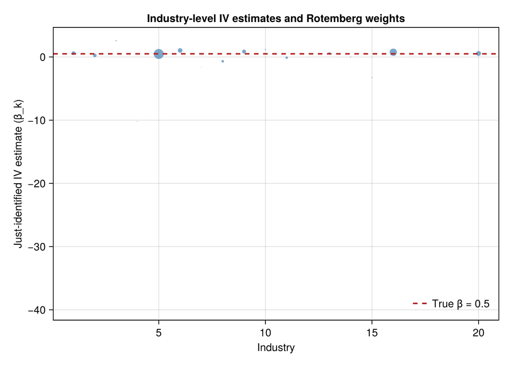

```julia
fig = Figure(size = (640, 380))
ax  = Axis(fig[1, 1],
           xlabel = "Industry",
           ylabel = "Just-identified IV estimate (β_k)",
           title  = "Industry-level IV estimates and Rotemberg weights")

# Bubble plot: position = beta_k, size = |alpha_k|
scatter!(ax, rw.industry, rw.beta_k,
         markersize = 30 .* sqrt.(abs.(rw.alpha)),
         color = (:steelblue, 0.7))
hlines!(ax, [beta_true], color = :firebrick, linestyle = :dash,
        linewidth = 2, label = "True β = $(beta_true)")
axislegend(ax, position = :rb, framevisible = false)
fig
```

### 18.4.2 What goes wrong when shares are endogenous

Now break the share-exogeneity assumption: make industry 1’s share correlated with the second-stage error. Under the share-exogeneity view of GPSS that alone makes the instrument invalid. Under the shock view of BHJ, endogenous shares are allowed, but only because many independent shocks average the share-confounder correlation away. With twenty industries and one realized set of shocks, industry 1’s shock does not average out, so the shock argument fails here too, for a different reason.

```julia
v = CSV.read("data/shift_share_bad_v.csv", DataFrame).v
shares_bad = copy(shares)
shares_bad[:, 1] .= max.(0.01, shares[:, 1] .+ 0.15 .* v)
shares_bad = shares_bad ./ sum(shares_bad, dims=2)   # renormalise

bad_noise = CSV.read("data/shift_share_bad_noise.csv", DataFrame)
B_bad = bartik_iv(shares_bad, shocks)
X_bad = B_bad .+ 0.3 .* u .+ bad_noise.noise_x
Y_bad = beta_true .* X_bad .+ u .+ 0.6 .* v .+ bad_noise.noise_y

df_bad  = DataFrame(X = X_bad, Y = Y_bad, B = B_bad)
iv_bad  = feiv(df_bad, @formula(Y ~ 1), endo = :X, inst = :B)

@printf("True beta: %.3f\n", beta_true)
@printf("Shift-share IV with bad share 1: %.3f\n", coef(iv_bad)[1])

# Would the Rotemberg weights have flagged industry 1?
rw_bad = rotemberg_weights(shares_bad, shocks, X_bad, Y_bad)
ord    = sortperm(abs.(rw_bad.alpha), rev = true)
rank1  = findfirst(==(1), rw_bad.industry[ord])
@printf("Rotemberg weight of industry 1: %.3f (rank %d of %d by |α|)\n",
        rw_bad.alpha[rw_bad.industry .== 1][1], rank1, nrow(rw_bad))

# Leave-one-industry-out: rebuild the instrument without industry 1
B_loo  = bartik_iv(shares_bad[:, 2:end], shocks[2:end])
df_loo = DataFrame(X = X_bad, Y = Y_bad, B = B_loo)
iv_loo = feiv(df_loo, @formula(Y ~ 1), endo = :X, inst = :B)
@printf("Leave-industry-1-out IV: %.3f\n", coef(iv_loo)[1])
```

```
True beta: 0.500
Shift-share IV with bad share 1: 0.798
Rotemberg weight of industry 1: 0.110 (rank 3 of 20 by |α|)
Leave-industry-1-out IV: 0.480
```

The estimate is biased, and the bias comes from one industry’s share being related to the error. Note what the diagnostics do and do not catch here. The endogenous industry’s Rotemberg weight is unremarkable — it ranks third of twenty — because the weights measure *influence* (whose exogeneity the estimate leans on most), not *endogeneity*. An industry with a modest weight can still move the estimate substantially when its share is correlated with the error. What points to the problem is the **leave-one-industry-out** check: dropping industry 1 from the instrument restores an estimate close to the truth. The isolation is not clean. Renormalizing the rows put the confounder into every share, so the remaining nineteen shares still carry it; the return toward the truth says that contamination is small in this draw.

## 18.5 BHJ shock-level inference

Collapse the location-level data to the shock level and run a weighted IV at the shock (industry) level. This reframes the identifying assumption: shocks must be uncorrelated with the shock-level aggregated outcome residual.

```julia
collapsed = bhj_collapse(shares, shocks, Y, X)

# BHJ shock-level 2SLS: regress Y_agg ~ X_agg | shock, weighted by weight
df_collapsed = collapsed
iv_bhj = feiv(df_collapsed, @formula(Y_agg ~ 1),
              endo = :X_agg, inst = :shock, weights = :weight)

@printf("Location-level shift-share IV: %.3f\n", coef(ivss)[1])
@printf("BHJ shock-level IV:             %.3f\n", coef(iv_bhj)[1])
@printf("(Identical in the no-controls case)\n")
```

```
Location-level shift-share IV: 0.531
BHJ shock-level IV:             0.531
(Identical in the no-controls case)
```

The BHJ shock-level regression gives exactly the location-level IV estimate when there are no controls. Its value is interpretive: validity is now a statement about shocks (20 observations, one per industry) rather than locations (500 observations), and testing shock-level exogeneity is more transparent.

## 18.6 Empirical: the China shock (Autor, Dorn, Hanson 2013)

The standard shift-share application is ADH (2013). Commuting zones are exposed differently to Chinese import competition because their baseline industry mixes differ. The instrument is

$$\text{IV}_\ell \;=\; \sum_k \frac{L_{\ell k,\,1990}}{L_{\ell,\,1990}}\,
\frac{\Delta M^{\text{other}}_{k}}{L_{k,\,1990}},
\tag{18.5}$$

where the shocks $\Delta M^{\text{other}}_k$ are growth in Chinese imports into other high-income countries. This leave-one-out construction removes US-specific demand from the shock.

The snippet below is schematic — the full ADH specification additionally needs period effects, the ADH control set, and population weights (a validated replication against the GPSS benchmark lives in the `ShiftShareIV.jl` repository).

```julia
# David Dorn distributes the replication data at ddorn.net
# Files needed:
#   workfile_china.csv  (commuting zone data, 1990–2007)
#   industry_shares.csv (czone × industry shares)

using CSV
cz     = DataFrame(CSV.File("data/workfile_china.csv"))
shares = Matrix(select(cz, r"share_"))   # L × K share matrix
shocks = cz.import_shock_other            # K-vector of "other-countries" shocks

B   = bartik_iv(shares, shocks)               # Bartik instrument
df_adh = hcat(cz, DataFrame(B = B))

# First-stage + second-stage
iv_adh = feiv(df_adh, @formula(d_sh_empl_mfg ~ 1),
              endo = :d_tradeusch_pw, inst = :B,
              vcov_type = Vcov.cluster(:statefip))

# Rotemberg decomposition
rw_adh = rotemberg_weights(shares, shocks, df_adh.d_tradeusch_pw,
                           df_adh.d_sh_empl_mfg)
# Top 5 industries by |alpha|:
sort(rw_adh, :alpha, rev=true)[1:5, :]

# BHJ shock-level regression
collapsed_adh = bhj_collapse(shares, shocks, df_adh.d_sh_empl_mfg,
                             df_adh.d_tradeusch_pw)
iv_bhj_adh = feiv(collapsed_adh, @formula(Y_agg ~ 1),
                  endo = :X_agg, inst = :shock, weights = :weight)
```

## 18.7 Summary

- Shift-share IV combines local shares and industry shocks.
- The GPSS view puts exogeneity on shares; the BHJ view puts it on shocks.
- Rotemberg weights show which industry shares drive the 2SLS estimate.
- Region-level clustering is usually too optimistic. Use shock-level inference and AKM standard errors when possible.
- `ShiftShareIV.jl` provides `bartik_iv`, `rotemberg_weights`, and `bhj_collapse`; `Panelest.jl` provides `feols` and `feiv`.